# Document 3- R codes for the asymptotic analyses of a stage-structured matrix model for spotted hyenas infected with CDV

S. Benhaiem, L. Marescot

2018-05-17 21:33:33

This code presents the stochastic analysis of the matrix model. To calculate standard deviations of ($\lambda$) and R0 (Figure 1), confidence intervals for the sensitivity analysis of ($\lambda$) and R0 (Figures 2,3) and to describe changes in population size over time while accounting for parameter uncertainty (Figure 5), we used Monte Carlo iterations.

This code is structured as follows:

1. Monte Carlo iterations to calcule the mean + SD of the population’s growth rate (Fig 1A), R0 (Fig 1B) and population abundance (Fig 5).
1. Plotting mean + SD of population’s growth rate and R0 (Fig 1)
2. Plotting changes in population abundance - complete model and “no rank” model (Fig 5)
2. Sensitivity analysis of the population’s growth rate ($\lambda$)(Fig 2)
3. Sensitivity analysis of R0 (Fig 3)

Note that parameter and submatrix names may differ between main text and R codes.

1. Monte Carlo iterations to calculate the mean + SD of the population’s growth rate (Fig1A) R0 (Fig1B) and population abundance (Fig5)

First, we create a function to compile the population indicators we are interested in; i.e. the mean population growth rate, R0, the population size, the sensitivity values of growth rate and R0 and their associated standard deviations.

```r
library(popdemo)
library(popbio)

# First we create the function to store the population indicators we are interested in

  results<-function(Mproj, NGMstoch, popvec, senslambda, theta){

  tabmoy<-matrix(0,2,2)
  rownames(tabmoy)<-c("lambda", "rnot")
  colnames(tabmoy)<-c("mean", "sd")

  # Lambda
  alllambda<-unlist(lapply(Mproj, lambda))
  mean_lambda<-mean(alllambda)
  sd_lambda<-sd(alllambda)
  tabmoy[1,1]<-mean_lambda
  tabmoy[1,2]<-sd_lambda

  # R0
  allrnot<-unlist(lapply(NGMstoch, lambda))
  mean_rnot<-mean(allrnot)
  sd_rnot<-sd(allrnot)
  tabmoy[2,1]<-mean_rnot
  tabmoy[2,2]<-sd_rnot

  # Population size
  popsizeMean <- apply(popvec, 1, mean)
  popsizeSD <- apply(popvec, 1, sd)

  # Sensitivity of lambda (Mean +SD)
  meansens<-matrix(0, nrow=MCiter, ncol=42)

  for (i in 1:MCiter)
  meansens[i,]<-t(senslambda[[i]][2])

  sens_lambdaMean<-colMeans(meansens)
  sens_lambdaSD <- apply(meansens,2,sd)
  names(sens_lambdaMean) <- rownames((senslambda[[1]]))
  names(sens_lambdaSD) <- rownames((senslambda[[1]]))


  # Sensitivity of R0 (Mean +SD)
  #preparing empty table where we   get the mean + SD of sens values
  SensR0<- matrix(data = 0, nrow=ncol(theta), ncol=3)# here empty

  #########----------- running the function which caluculates the senstivity of R0
if(t == "epidem")
{
  for(r in 1:ncol(theta))
{
  sensi<- sens_elas_num(r, theta, delta=1e-4) # here we apply the sens_elas_num function! r = pos
  SensR0[r,2]<-as.numeric(mean(sensi[[2]]))
  SensR0[r,3]<-as.numeric(sd(sensi[[2]]))
  SensR0[r,1]<-as.character(sensi[[1]])
}
}

  return(list(tabmoy, popsizeMean, popsizeSD, sens_lambdaMean, sens_lambdaSD, SensR0))
}
```

```r
data<-read.table("./RegressionCoefficient.txt", header = TRUE) #CHANGE NAME --> data is not good

MCiter<-1000 # Number of Monte Carlo iterations

checkNodisease <- FALSE # Check if we are in the projection phase were the disease is extinct (then set the infection probaility to 0 in the MC_simualtionsUnique.R file)
# Pre-epidemic period (1990-1992)
t<-"pre-epidem"
period <- t
popsize0<-100
Tmax<-3
source('MC_simulations.R')

tabprepidem<-results(Mproj, NGMstoch, popvec,senslambda, theta)

# Epidemic period (1993-1994)
t<-"epidem"
period <- t
Tmax<-3
popsize0<-tabprepidem[[2]][3]
source('MC_simulations.R')
tabepidem<-results(Mproj, NGMstoch, popvec,senslambda, theta)

# Post-epidemic period (1995-1999)
t<-"post-epidem1"
period <- t
Tmax<-6
popsize0<-tabepidem[[2]][3]
source('MC_simulations.R')
tabpost1<-results(Mproj, NGMstoch, popvec,senslambda, theta)

# Period of virus absence in the ecosystem (2000-2010)
t<-"post-epidem2"
period <- t
Tmax<-12
popsize0<-tabpost1[[2]][6]

source('MC_simulations.R')
tabpost2<-results(Mproj, NGMstoch, popvec,senslambda, theta)

# Projections in the future (2010 to 2020)
Tmax<-13
checkNodisease == TRUE
```

```
## [1] FALSE
```

```r
popsize0<-tabpost2[[2]][12]
source('MC_simulations.R')
tabprojection<-results(Mproj, NGMstoch, popvec,senslambda, theta)
```

1. Plotting mean + SD of population’s growth rate and R0 (Fig1)

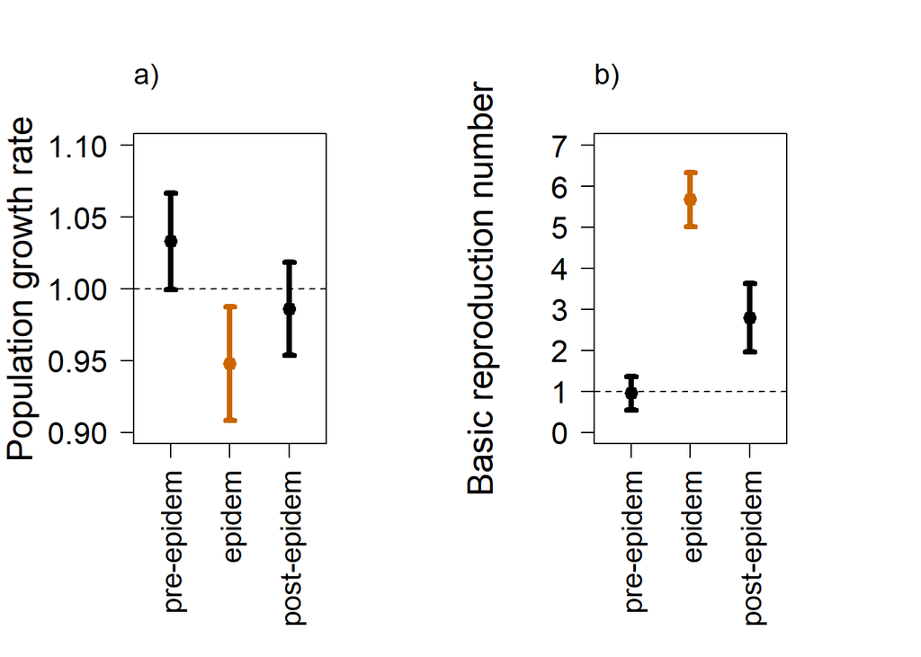

```r
data2 <- matrix(0,3,4)
colnames(data2) <- c("R0.mean", "R0.SD","Lambda", "Lambda.SD")
rownames(data2) <- c("pre-epidem", "epidem","post-epidem1")

data2[1,3]<-tabprepidem[[1]][1,1] # mean lambda
data2[1,4]<-tabprepidem[[1]][1,2] # SD lambda
data2[1,1]<-tabprepidem[[1]][2,1] # mean R0
data2[1,2]<-tabprepidem[[1]][2,2] # SD R0

data2[2,3]<-tabepidem[[1]][1,1] # mean lambda
data2[2,4]<-tabepidem[[1]][1,2] # SD lambda
data2[2,1]<-tabepidem[[1]][2,1] # mean R0
data2[2,2]<-tabepidem[[1]][2,2] # SD R0

data2[3,3]<-tabpost1[[1]][1,1] # mean lambda
data2[3,4]<-tabpost1[[1]][1,2] # SD lambda
data2[3,1]<-tabpost1[[1]][2,1] # mean R0
data2[3,2]<-tabpost1[[1]][2,2] # SD R0

par(mfrow=c(1,2))

x<-c(0.5,1,2,3,3.5)

colvec <- c("white","black","#CC6600","black","white")

# -------------------- > lambda

mean<-c(0,data2[c("pre-epidem","epidem","post-epidem1"),3],0)
sd<-c(0,data2[c("pre-epidem","epidem","post-epidem1"),4],0)

mean<-as.numeric(mean)
sd<-as.numeric(sd)

library(plotrix)

par(mar=c(8.1,5.1,5.1,5.1))
plotCI(x,mean,
       uiw=sd, err="y",las=1, ylab = "", cex=1.4,xaxt="n", ylim=c(0.90,1.10),xlab ="", cex.axis=1.4,
       lwd=4, pch=20, col =colvec)

names(x)<-c("pre-epidem","epidem","post-epidem","")
colvec2 <-c("black","#CC6600","black")

axis(side=1,at=c(1:5),label=names(x),cex.axis=1.3, las =2)
mtext(side = 2, text ="Population growth rate", line = 3.7, cex=1.6)
abline(h=1, lty=2)
mtext(side = 3,text=c("a)"),adj=0, line =1.7,cex = 1.3)


mean1<-c(-0.5,data2[c("pre-epidem","epidem","post-epidem1"),1],-0.5)
sd1<-c(-0.5,data2[c("pre-epidem","epidem","post-epidem1"),2],-0.5)

mean1<-as.numeric(mean1)
sd1<-as.numeric(sd1)

colvec1 <- c("black","black","#CC6600","black")

plotCI(x,mean1,
       uiw=sd1, err="y",las=1, ylab = "", cex=1.4,xaxt="n",
       ylim=c(0,7),xlab ="", cex.axis=1.4,
       lwd=4, pch=20, col=colvec1)

names(x)<-c("pre-epidem","epidem","post-epidem","")
axis(side=1,at=c(1:5),label=names(x),cex.axis=1.3,las =2)
mtext(side = 2, text ="Basic reproduction number", line = 3.7, cex=1.6)
abline(h=1, lty=2)
mtext(side = 3,text=c("b)"),adj=0, line =1.7,cex = 1.3)
```

2. Plotting changes in population abundance - complete model and “no rank” model Fig5)

We can then describe past (1990-2010) and predicted (2011-2020) temporal changes in population abundance (Figure 5) given parameter uncertainty during the 20 years of survey (1990-2010).

- To describe the past temporal changes during the study period (1990-2010) we calculated 1000 values of population growth rate for each year of the study period accounting for temporal variations in the mean estimates between the pre-epidemic, epidemic and post-epidemic phases. We described with a Markov chain the changes in population size by mutliplying population vector of a given year by lambda and reinitialiaze the population vector to the resulting vector of next year abundance. the initial population vector was defined as the product of 100 individuals and the stable stage distribution.
- To predict abundance of spotted hyenas for 10 years after the end of the study period (i.e. 2011-2020) (see MCSimulations_postepidem.R), we considered the 1000 block-matrices M implemented with the MECMR parameter estimates associated with the second post-epidemic period (2000-2010), and we determined the population vector of the number of individuals in the 22 demographic, social and infection states during the last year of the survey (2010). This vector was defined as the product of the mean abundance estimated in 2010 and the stable stage distribution. We then multiplied the matrices with this population vector to obtain 1000 population vectors and calculate the confidence intervals of the abundance the following year. These population vectors were then multiplied again by the simulated matrices to calculate the mean abundance and its associated confidence interval in the following year. In such case the range of abundance increases with time as we use all the poulation vectors from a previous year (and not only the mean one) to calculate the range of population sizes the next year, accounting for the uncertainty around the parameter estimates. This Markov chain in which the population vectors of the next year only depend on the population vectors of the current year and of the simulated projection matrices was then reiterated for 10 years.

```r
lambdaseq <- c(rep(tabprepidem[[1]][1,1], 3), rep(tabepidem[[1]][1,1], 2) , rep(tabpost1[[1]][1,1], 5),rep(tabpost2[[1]][1,1], 11),rep(tabprojection[[1]][1,1], 10))

lambdase <- c(rep(tabprepidem[[1]][1,2], 3), rep(tabepidem[[1]][1,2], 2) , rep(tabpost1[[1]][1,2], 5),rep(tabpost2[[1]][1,2], 11),rep(tabprojection[[1]][1,2], 10))

popproj<-rep(0,31)
popproj[1]<-100
varmoins<-rep(0,31)
varplus<-rep(0,31)
varplus[1]<-100
varmoins[1]<-100


for(t in 2:21)
{
  popproj[t]<-popproj[t-1] * lambdaseq[t]
  varplus[t]<-popproj[t-1]  * (lambdaseq[t] + lambdase[t])
  varmoins[t]<-popproj[t-1]  * (lambdaseq[t] - lambdase[t])
}

p<-1
for(t in 23:32)
{
  p<-p+1
  popproj[t]<- tabprojection[[2]][p]
  varplus[t]<- tabprojection[[2]][p] +  tabprojection[[3]][p]
  varmoins[t]<- tabprojection[[2]][p] - tabprojection[[3]][p]
}

# Here We delete the meaningless growth rate obtained at the first year of predicitons phase, which correponds to  a year of transition between the descriptive and predicitve part of the analysis
popproj<-popproj[-22]
varplus<-varplus [-22]
varmoins<-varmoins[-22]

####

mat2 <- cbind(popproj,varmoins,varplus)

mat2<-as.data.frame(mat2)
mat2$Model<-rep("normal", 31)
mat2$Time<-1:31
mat2$Time1 <-c(1990:2020)

mat2
```

```
##      popproj  varmoins   varplus  Model Time Time1
## 1  100.00000 100.00000 100.00000 normal    1  1990
## 2  103.32282  99.96951 106.67613 normal    2  1991
## 3  106.75605 103.29131 110.22079 normal    3  1992
## 4  101.21152  96.99050 105.43255 normal    4  1993
## 5   95.95496  91.95316  99.95676 normal    5  1994
## 6   94.62679  91.52612  97.72747 normal    6  1995
## 7   93.31701  90.25925  96.37477 normal    7  1996
## 8   92.02535  89.00992  95.04079 normal    8  1997
## 9   90.75158  87.77788  93.72527 normal    9  1998
## 10  89.49543  86.56290  92.42797 normal   10  1999
## 11  90.33602  87.90739  92.76465 normal   11  2000
## 12  91.18450  88.73307  93.63594 normal   12  2001
## 13  92.04096  89.56649  94.51542 normal   13  2002
## 14  92.90546  90.40775  95.40316 normal   14  2003
```

[output cut: 17 more lines]

In the next step we repeat this procedure for the model “no rank”.

```r
data<-read.table("./RegressionCoefficientNORANK.txt", header = TRUE)

checkNodisease <- FALSE
t<-"pre-epidem"
period<-t
popsize0<-100
Tmax<-3
source('MC_simulations.R')
tabprepidemNR<-results(Mproj, NGMstoch, popvec, senslambda, theta)

t<-"epidem"
period<-t
Tmax<-3
popsize0<-tabprepidemNR[[2]][3]
source('MC_simulations.R')
tabepidemNR<-results(Mproj, NGMstoch, popvec, senslambda, theta)

t<-"post-epidem1"
period<-t
Tmax<-6
popsize0<-tabepidemNR[[2]][3]
source('MC_simulations.R')
tabpost1NR<-results(Mproj, NGMstoch, popvec, senslambda, theta)

t<-"post-epidem2"
Tmax<-12
period<-t
popsize0<-tabpost1NR[[2]][6]
source('MC_simulations.R')

tabpost2NR<-results(Mproj, NGMstoch, popvec, senslambda, theta)

Tmax<-13
period<-t
checkNodisease <- TRUE
popsize0<-tabpost2NR[[2]][12]
source('MC_simulations.R')
tabprojectionNR<-results(Mproj, NGMstoch, popvec, senslambda, theta)
```

We store in a data frame the population vectors describing variations in expected abundance over 30 years, in both model with and without rank effect.

```r
lambdaseq <- c(rep(tabprepidemNR[[1]][1,1], 3), rep(tabepidemNR[[1]][1,1], 2) , rep(tabpost1NR[[1]][1,1], 5),rep(tabpost2NR[[1]][1,1], 11),rep(tabprojectionNR[[1]][1,1], 10))

lambdase <- c(rep(tabprepidemNR[[1]][1,2], 3), rep(tabepidemNR[[1]][1,2], 2) , rep(tabpost1NR[[1]][1,2], 5),rep(tabpost2NR[[1]][1,2], 11),rep(tabprojectionNR[[1]][1,2], 10))


popproj<-rep(0,31) # vecteur avec 31fois 0
popproj[1]<-100 # on replace la premiere entree par 100
varmoins<-rep(0,31)
varplus<-rep(0,31)
varplus[1]<-100 # pas d erreur sur la premiere valeur
varmoins[1]<-100 # pas d erreur sur la premiere valeur


# loop on the retrospective (1990 to 2010)

for(t in 2:21) # starts at 2 because t-1 if t=1 is 0
{
  popproj[t]<-popproj[t-1] * lambdaseq[t]
  varplus[t]<-popproj[t-1]  * (lambdaseq[t] + lambdase[t])
  varmoins[t]<-popproj[t-1]  * (lambdaseq[t] - lambdase[t])
}

# Projections 2000-2010

p<-1
for(t in 22:33)
{
  p<-p+1 # to move to the next value
  popproj[t]<- tabprojectionNR[[2]][p]
  varplus[t]<- tabprojectionNR[[2]][p] + tabprojectionNR[[3]][p]
  varmoins[t]<- tabprojectionNR[[2]][p] - tabprojectionNR[[3]][p]
}

# delete 2011/2012
popproj<-popproj[-22]
varplus<-varplus [-22]
varmoins<-varmoins[-22]

popproj<-popproj[-22]
varplus<-varplus [-22]
varmoins<-varmoins[-22]

matNR <- cbind(popproj,varmoins,varplus)
matNR<-as.data.frame(matNR)
matNR$Model<-rep("NR", 31)

matNR$Time<-1:31
matNR$Time1 <-c(1990:2020)


matNEW <-rbind(mat2,matNR)
matNEW
```

```
##      popproj  varmoins   varplus  Model Time Time1
## 1  100.00000 100.00000 100.00000 normal    1  1990
## 2  103.32282  99.96951 106.67613 normal    2  1991
## 3  106.75605 103.29131 110.22079 normal    3  1992
## 4  101.21152  96.99050 105.43255 normal    4  1993
## 5   95.95496  91.95316  99.95676 normal    5  1994
## 6   94.62679  91.52612  97.72747 normal    6  1995
## 7   93.31701  90.25925  96.37477 normal    7  1996
## 8   92.02535  89.00992  95.04079 normal    8  1997
## 9   90.75158  87.77788  93.72527 normal    9  1998
## 10  89.49543  86.56290  92.42797 normal   10  1999
## 11  90.33602  87.90739  92.76465 normal   11  2000
## 12  91.18450  88.73307  93.63594 normal   12  2001
## 13  92.04096  89.56649  94.51542 normal   13  2002
## 14  92.90546  90.40775  95.40316 normal   14  2003
```

[output cut: 48 more lines]

Then we plot Figure 5:

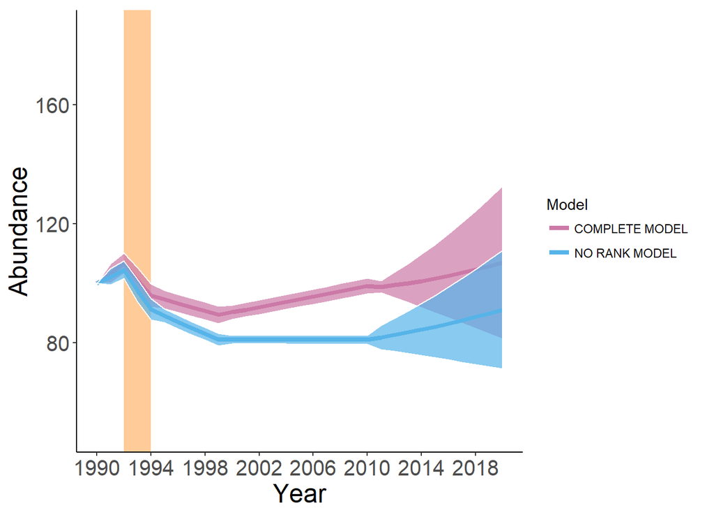

```r
library(ggplot2)
p <- ggplot(data=matNEW, aes(x=Time1, y=popproj, ymin=varmoins, ymax=varplus)) +

  geom_rect(aes(xmin=1992, xmax=1994, ymin=-Inf, ymax=Inf), fill="#FFCC99",alpha=0.5) +

  geom_line(data=matNEW[matNEW$Model=="normal", ],aes(colour="myline1",x=Time1, y=popproj),size=1.5) +
  geom_ribbon(data=matNEW[matNEW$Model=="normal", ],alpha=0.7, color= "white",fill ="#CC79A7")  + xlab("Year") + ylab("Abundance") +

  geom_line(data=matNEW[matNEW$Model=="NR", ],aes(colour="myline2",x=Time1, y=popproj),size=1.5) +
  geom_ribbon(data=matNEW[matNEW$Model=="NR", ],alpha=0.7, color= "white",fill ="#56B4E9") + xlab("Year") + ylab("Abundance") +

  scale_colour_manual(name="Model",values=c(myline1="#CC79A7", myline2="#56B4E9"),
                      labels = c("COMPLETE MODEL", "NO RANK MODEL")) +
  ylim(50, 185) +

  scale_x_continuous(breaks = round(seq(min(matNEW$Time1), max(matNEW$Time1), by = 4),1))


p + theme_bw() +

  theme(
    axis.line = element_line(colour = "black"),
    axis.text = element_text(size=15),
    panel.grid.major = element_blank(),
    panel.grid.minor = element_blank(),
    panel.border = element_blank(),
    panel.background = element_blank(),
    axis.title.x = element_text(colour="black",size=18,angle=0,hjust=.5,vjust=0,face="plain"),
    axis.title.y = element_text(colour="black",size=18),
    plot.margin = unit(c(7.5, 12.5, 5.5, 5.5), "points")
  )
```

3. Sensitivity analyses of the population’s growth rate ($\lambda$)(Fig2)

To determine which parameters contributed most to($\lambda$) and predict the results of future changes in parameter estimates, we performed a sensitivity analysis. When elements of a population matrix are composed of several vital rates, the classical first order sensitivity analysis is not recommended, as it does not allow disentangling the effects of demographic, social and infection parameters. Therefore, we conducted lower-level sensitivity analyses for ($\lambda$). In the source file **MCSimulations** and **MCSimulations_postepidem** we applied the function ‘vitalsens’ from the R package ’popbio which evaluate the expression oft the matrix projection using all parameter values of the MonteCarlo iterations.

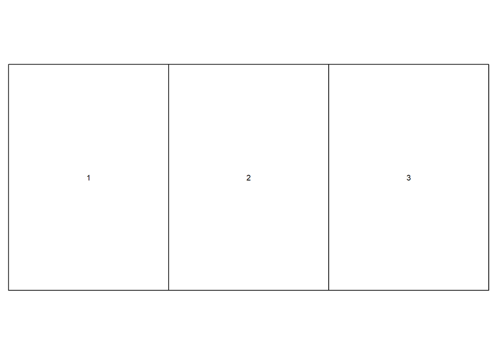

```r
nf <- layout(matrix(c(0,0,0,0,1,0,0,2,0,0,3,0,0,0,0),3, byrow = FALSE),
             widths= c(0.1,1.8,1.8,1.8,0.1), heights=c(1,3.5,1,1,0)) # widths for columns,heights for rows
layout.show(nf)
```

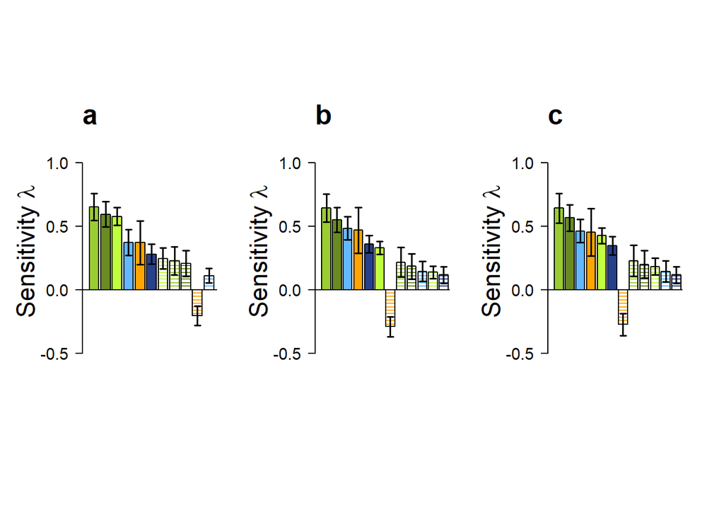

```r
 figtab<-cbind(as.numeric(tabprepidem[[4]]), as.numeric(tabprepidem[[5]]), as.numeric(tabepidem[[4]]), as.numeric(tabepidem[[5]]), as.numeric(tabpost1[[4]]), as.numeric(tabpost1[[5]]), as.numeric(tabpost2[[4]]), as.numeric(tabpost2[[5]])) # removes the character names and the ""



  colnames(figtab)<-c("sens_preepidem","sd_preepidem", "sens_epidem","sd_epidem", "sens_postepidem1","sd_postepidem1", "sens_postpidem2","sd_postepidem2")

  figtab<-as.data.frame(figtab)
  figtab$param<-names(tabepidem[[5]])
#-------- Pre-Epidem
# 1) Select sens values whose abs. value is higher than 10%
sensNew<-subset(figtab, abs(figtab$sens_preepidem) >= 0.10)

# 2) Order by decreasing importance
sensNew1<-sensNew[order(abs(sensNew$sens_preepidem),decreasing=TRUE),] # Order from highest impact on lambda to

# -- Plot; decreasing importance

par(mar=c(5.1,5.1,4.1,2.1))

color = rep(NA, length=length(sensNew1$param))

color[which(sensNew1$param=="bSH")] = "olivedrab1"
color[which(sensNew1$param=="bBH")] = "olivedrab3"
color[which(sensNew1$param=="bNBH")] = "olivedrab4"

color[which(sensNew1$param=="bSL")] = "olivedrab1"
color[which(sensNew1$param=="bBL")] = "olivedrab3"
color[which(sensNew1$param=="bNBL")] = "olivedrab4"

color[which(sensNew1$param=="rHH.R")] = "orange1"
color[which(sensNew1$param=="rLL.R")] = "orange1"

color[which(sensNew1$param=="phiBHR")] = "royalblue4"
color[which(sensNew1$param=="phiNBHR")] = "steelblue1"

#color[which(sensNew1$param=="phiBHS")] = "skyblue3"
#color[which(sensNew1$param=="phiNBHS")] = "skyblue1"

#color[which(sensNew1$param=="phiBLR")] = "royalblue4"
color[which(sensNew1$param=="phiNBLR")] = "steelblue1"

#color[which(sensNew1$param=="phiBLS")] = "skyblue3"
#color[which(sensNew1$param=="phiNBLS")] = "skyblue1"

dashed = rep(NA, length=length(sensNew1$param))
dashed[which(sensNew1$param=="bSH")] = NA
dashed[which(sensNew1$param=="bBH")] = NA
dashed[which(sensNew1$param=="bNBH")] = NA

dashed[which(sensNew1$param=="bSL")] = 30
dashed[which(sensNew1$param=="bBL")] = 30
dashed[which(sensNew1$param=="bNBL")] = 30

dashed[which(sensNew1$param=="rHH.R")] = NA
dashed[which(sensNew1$param=="rLL.R")] = 30

dashed[which(sensNew1$param=="phiBHR")] = NA
dashed[which(sensNew1$param=="phiNBHR")] = NA

#dashed[which(sensNew1$param=="phiBHS")] = NA
#dashed[which(sensNew1$param=="phiNBHS")] = NA

#dashed[which(sensNew1$param=="phiBLR")] = 80
dashed[which(sensNew1$param=="phiNBLR")] = 30

#dashed[which(sensNew1$param=="phiBLS")] = 80
#dashed[which(sensNew1$param=="phiNBLS")] = 80



bp<-barplot(sensNew1$sens_preepidem, las=1,col=color, ylab=(expression("Sensitivity "*lambda)), cex =0.6,
            xpd=FALSE, main="", ylim=c(-0.5,1.1), cex.lab = 2.2,
            cex.axis= 1.4,xlim=c(0,13), density=dashed, angle =0)

lines(c(-0.75,20),c(0,0))

arrows(bp, sensNew1$sens_preepidem - sensNew1$sd_preepidem , bp,
       sensNew1$sens_preepidem + sensNew1$sd_preepidem  , lwd = 1.5, angle = 90,
       code = 3, length = 0.03)
#mtext(side = 3,text=c("a) pre-epidem"),adj=0, line =1.7,cex = 1.3)

mtext(side = 3,text= expression(paste(bold("a"))),adj=0, line =1.7,cex = 1.6)



#-------- Epidem
# 1) Select sens values whose abs. value is higher than 10%
sensNew<-subset(figtab, abs(figtab$sens_epidem) >= 0.10)

# 2) Order by decreasing importance
sensNew1<-sensNew[order(abs(sensNew$sens_epidem),decreasing=TRUE),] # Order from highest impact on lambda to
#n =12
# -- Plot; decreasing importance

par(mar=c(5.1,5.1,4.1,2.1))

color = rep(NA, length=length(sensNew1$param))

color[which(sensNew1$param=="bSH")] = "olivedrab1"
color[which(sensNew1$param=="bBH")] = "olivedrab3"
color[which(sensNew1$param=="bNBH")] = "olivedrab4"

color[which(sensNew1$param=="bSL")] = "olivedrab1"
color[which(sensNew1$param=="bBL")] = "olivedrab3"
color[which(sensNew1$param=="bNBL")] = "olivedrab4"

color[which(sensNew1$param=="rHH.R")] = "orange1"
color[which(sensNew1$param=="rLL.R")] = "orange1"

color[which(sensNew1$param=="phiBHR")] = "royalblue4"
color[which(sensNew1$param=="phiNBHR")] = "steelblue1"

color[which(sensNew1$param=="phiBHS")] = "skyblue3"
color[which(sensNew1$param=="phiNBHS")] = "skyblue1"

color[which(sensNew1$param=="phiBLR")] = "royalblue4"
color[which(sensNew1$param=="phiNBLR")] = "steelblue1"

#color[which(sensNew1$param=="phiBLS")] = "skyblue3"
#color[which(sensNew1$param=="phiNBLS")] = "skyblue1"

dashed = rep(NA, length=length(sensNew1$param))
dashed[which(sensNew1$param=="bSH")] = NA
dashed[which(sensNew1$param=="bBH")] = NA
dashed[which(sensNew1$param=="bNBH")] = NA

dashed[which(sensNew1$param=="bSL")] = 30
dashed[which(sensNew1$param=="bBL")] = 30
dashed[which(sensNew1$param=="bNBL")] = 30

dashed[which(sensNew1$param=="rHH.R")] = NA
dashed[which(sensNew1$param=="rLL.R")] = 30

dashed[which(sensNew1$param=="phiBHR")] = NA
dashed[which(sensNew1$param=="phiNBHR")] = NA

#dashed[which(sensNew1$param=="phiBHS")] = NA
#dashed[which(sensNew1$param=="phiNBHS")] = NA

dashed[which(sensNew1$param=="phiBLR")] = 30
dashed[which(sensNew1$param=="phiNBLR")] = 30

#dashed[which(sensNew1$param=="phiBLS")] = 80
#dashed[which(sensNew1$param=="phiNBLS")] = 80

bp<-barplot(sensNew1$sens_epidem, las=1,col=color, ylab=(expression("Sensitivity "*lambda)), cex =0.6,
            xpd=FALSE, main="", ylim=c(-0.5,1.1),
            cex.lab = 2.2, cex.axis= 1.4,xlim=c(0,14),density=dashed, angle =0) # xpd = Should bars be allowed to go outside region?
lines(c(-0.75,20),c(0,0))

arrows(bp, sensNew1$sens_epidem - sensNew1$sd_epidem , bp,
       sensNew1$sens_epidem + sensNew1$sd_epidem  , lwd = 1.5, angle = 90,
       code = 3, length = 0.03)

#mtext(side = 3,text=c("b) epidem"),adj=0, line =1.7,cex = 1.3)
mtext(side = 3,text= expression(paste(bold("b"))),adj=0, line =1.7,cex = 1.6)

# Post-epidem

# 1) Select sens values whose abs. value is higher than 10%
sensNew<-subset(figtab, abs(figtab$sens_postepidem1) >= 0.10)

# 2) Order by decreasing importance
sensNew1<-sensNew[order(abs(sensNew$sens_postepidem1),decreasing=TRUE),] # Order from highest impact on lambda to

# -- Plot; decreasing importance

par(mar=c(5.1,5.1,4.1,2.1))
color = rep(NA, length=length(sensNew1$param))

color[which(sensNew1$param=="bSH")] = "olivedrab1"
color[which(sensNew1$param=="bBH")] = "olivedrab3"
color[which(sensNew1$param=="bNBH")] = "olivedrab4"

color[which(sensNew1$param=="bSL")] = "olivedrab1"
color[which(sensNew1$param=="bBL")] = "olivedrab3"
color[which(sensNew1$param=="bNBL")] = "olivedrab4"

color[which(sensNew1$param=="rHH.R")] = "orange1"
color[which(sensNew1$param=="rLL.R")] = "orange1"

color[which(sensNew1$param=="phiBHR")] = "royalblue4"
color[which(sensNew1$param=="phiNBHR")] = "steelblue1"

#color[which(sensNew1$param=="phiBHS")] = "skyblue3"
#color[which(sensNew1$param=="phiNBHS")] = "skyblue1"

color[which(sensNew1$param=="phiBLR")] = "royalblue4"
color[which(sensNew1$param=="phiNBLR")] = "steelblue1"

#color[which(sensNew1$param=="phiBLS")] = "skyblue3"
#color[which(sensNew1$param=="phiNBLS")] = "skyblue1"

dashed = rep(NA, length=length(sensNew1$param))
dashed[which(sensNew1$param=="bSH")] = NA
dashed[which(sensNew1$param=="bBH")] = NA
dashed[which(sensNew1$param=="bNBH")] = NA

dashed[which(sensNew1$param=="bSL")] = 30
dashed[which(sensNew1$param=="bBL")] = 30
dashed[which(sensNew1$param=="bNBL")] = 30

dashed[which(sensNew1$param=="rHH.R")] = NA
dashed[which(sensNew1$param=="rLL.R")] = 30

dashed[which(sensNew1$param=="phiBHR")] = NA
dashed[which(sensNew1$param=="phiNBHR")] = NA

#dashed[which(sensNew1$param=="phiBHS")] = NA
#dashed[which(sensNew1$param=="phiNBHS")] = NA

dashed[which(sensNew1$param=="phiBLR")] = 30
dashed[which(sensNew1$param=="phiNBLR")] = 30

#dashed[which(sensNew1$param=="phiBLS")] = 80
#dashed[which(sensNew1$param=="phiNBLS")] = 80

bp<-barplot(sensNew1$sens_postepidem1, las=1,col=color,ylab=(expression("Sensitivity "*lambda)), cex =0.6,
            xpd=FALSE, main="",
            density= dashed, angle =0,ylim=c(-0.5,1.1), cex.lab = 2.2, cex.axis= 1.4,xlim=c(0,14)) # xpd = Should bars be allowed to go outside region?
lines(c(-0.75,20),c(0,0))

arrows(bp, sensNew1$sens_postepidem1 - sensNew1$sd_postepidem1, bp,
       sensNew1$sens_postepidem1 + sensNew1$sd_postepidem1, lwd = 1.5, angle = 90,
       code = 3, length = 0.03)

#mtext(side = 3,text=c("c) post-epidem"),adj=0, line =1.7,cex = 1.3)
mtext(side = 3,text= expression(paste(bold("c"))),adj=0, line =1.7,cex = 1.6)
```

[figure not shown]

```r
# Overall legend

#rm(list=ls()) # remove all objects/memory
#gc()

par(mar=c(5.1,5.1,4.1,2.1))

plot(sensNew1$sens_postepidem1, pch ="",xlab="",ylab="")

legend("topright",

c("Breeding SA.H","Breeding SA.L","Breeding B.H","Breeding B.L","Breeding NB.H","Breeding NB.L",
 "Staying H","Staying L",
 "Survival C.H.S","Survival C.L.S", "Survival SA.H","Survival SA.L","Survival SA.I&R", "Survival B","Survival NB",
 "Infection C.H", "Infection C.L", "Infection SA.B.NB.H","Infection SA.B.NB.L",
 "Sex ratio")
       ,
       fill= c("olivedrab4", "olivedrab4", "olivedrab1","olivedrab1","olivedrab3","olivedrab3",
               "orange1","orange1",
               "cadetblue","cadetblue","aquamarine4","aquamarine4","aquamarine1","royalblue4","skyblue3",
               "darkmagenta","darkmagenta","darkorchid1","darkorchid1",
               "gray0")
,
       density = c(NA,80,NA,80,NA,80,
                   NA,80,
                   NA,80,NA,80,NA,NA,NA,
                   NA,80,NA,80,
                   NA))
```

4. Here we determine which parameters contributed most to variation in *R0* in order to predict future disease dynamics with changes in parameter $(\theta)$. Because we did not have a symbolic expression of the next generation matrix, we could not apply the vitalsens function as we did for calculating the sensitvity of lambda. Instead, we performed the sensitivity analysis of R0 by coding the following equation $\delta(R0)/\delta(\theta)$.

Now we plot the sensitivity value of R0

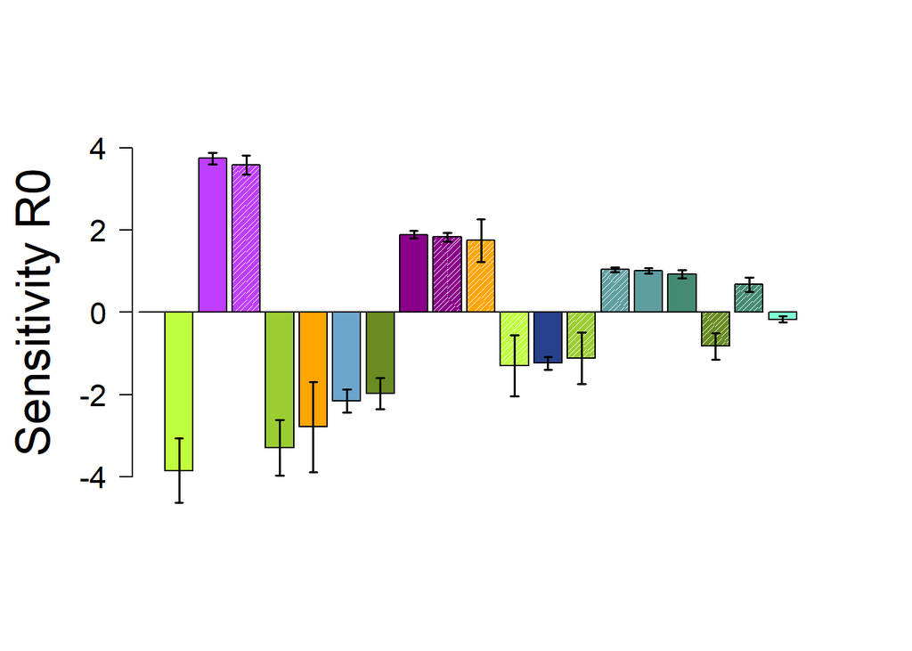

```r
figtab<-cbind(as.numeric(tabepidem[[6]][,2]), as.numeric(tabepidem[[6]][,3])) # removes the character names


colnames(figtab)<-c("sens_epidem","sd_epidem")

figtab<-as.data.frame(figtab)

figtab$sens_epidem[12:15]<- 1 - figtab$sens_epidem[12:15]

figtab$param<- as.character(tabepidem[[6]][,1])



#-------- Epidem
# 1) Select sens values whose abs. value is higher than 10%
sensNew<-subset(figtab, abs(figtab$sens_epidem) >= 0.10)

# 2) Order by decreasing importance
sensNew1<-sensNew[order(abs(sensNew$sens_epidem),decreasing=TRUE),] # Order from highest impact on lambda to

sensNew1$param<-c("Breeding_BH", "Infection_SA&B&NBH", "Infection_SA&B&NBL", "Breeding_NBH", "Staying_H", "Survival_NB", "Breeding_SAH", "Infection_CH", "Infection_CL", "Staying_L", "Breeding_BL", "Survival_B", "Breeding_NBL","Survival_CLS","Survival_CHS","Survival_SAHS","Breeding_SAL","Survival_SALS","Survival_SAI&R")

# -- Plot; decreasing importance

par(mar=c(5.1,5.1,4.1,2.1))

color = rep(NA, length=length(sensNew1$param))

# Survival
# cubs
color[which(sensNew1$param=="Survival_CHS")] = "cadetblue"
#color[which(sensNew1$param=="Survival_CHI")] = "cadetblue1"

color[which(sensNew1$param=="Survival_CLS")] = "cadetblue"
#color[which(sensNew1$param=="Survival_CLI")] = "cadetblue1"

# subadults
color[which(sensNew1$param=="Survival_SAHS")] = "aquamarine4"
color[which(sensNew1$param=="Survival_SAI&R")] = "aquamarine1"

color[which(sensNew1$param=="Survival_SALS")] = "aquamarine4"

#breeders
color[which(sensNew1$param=="Survival_B")] = "royalblue4"

#Nonbreeders
color[which(sensNew1$param=="Survival_NB")] = "skyblue3"

#rank transitions
color[which(sensNew1$param=="Staying_H")] = "orange1"
color[which(sensNew1$param=="Staying_L")] = "orange1"

# Infection proba
color[which(sensNew1$param=="Infection_CH")] = "darkmagenta"
color[which(sensNew1$param=="Infection_CL")] = "darkmagenta"

color[which(sensNew1$param=="Infection_SA&B&NBH")] = "darkorchid1"
color[which(sensNew1$param=="Infection_SA&B&NBL")] = "darkorchid1"

# Breeding
color[which(sensNew1$param=="Breeding_BH")] = "olivedrab1"
color[which(sensNew1$param=="Breeding_NBH")] = "olivedrab3"
color[which(sensNew1$param=="Breeding_SAH")] = "olivedrab4"

color[which(sensNew1$param=="Breeding_BL")] = "olivedrab1"
color[which(sensNew1$param=="Breeding_NBL")] = "olivedrab3"
color[which(sensNew1$param=="Breeding_SAL")] = "olivedrab4"

#Sex ratio
color[which(sensNew1$param=="SexRatio")] = "gray0"

dashed = rep(NA, length=length(sensNew1$param))

dashed[which(sensNew1$param=="Survival_CHS")] = NA
#dashed[which(sensNew1$param=="Survival_CHI")] = "cadetblue1"

dashed[which(sensNew1$param=="Survival_CLS")] = 80
#dashed[which(sensNew1$param=="Survival_CLI")] = "cadetblue1"

# subadults
dashed[which(sensNew1$param=="Survival_SAHS")] = NA
dashed[which(sensNew1$param=="Survival_SAI&R")] = NA

dashed[which(sensNew1$param=="Survival_SALS")] = 80

#breeders
dashed[which(sensNew1$param=="Survival_B")] = NA

#Nonbreeders
dashed[which(sensNew1$param=="Survival_NB")] = NA

#rank transitions
dashed[which(sensNew1$param=="Staying_H")] = NA
dashed[which(sensNew1$param=="Staying_L")] = 80

# Infection proba
dashed[which(sensNew1$param=="Infection_CH")] = NA
dashed[which(sensNew1$param=="Infection_CL")] = 80

dashed[which(sensNew1$param=="Infection_SA&B&NBH")] = NA
dashed[which(sensNew1$param=="Infection_SA&B&NBL")] = 80

# Breeding
dashed[which(sensNew1$param=="Breeding_BH")] = NA
dashed[which(sensNew1$param=="Breeding_NBH")] = NA
dashed[which(sensNew1$param=="Breeding_SAH")] = NA

dashed[which(sensNew1$param=="Breeding_BL")] = 80
dashed[which(sensNew1$param=="Breeding_NBL")] = 80
dashed[which(sensNew1$param=="Breeding_SAL")] = 80

#vec<-c( "trans.beta", "trans.beta", "trans.beta", "trans.beta", "trans.beta", "trans.beta", "fecundls",
#        "survivalL",  "survivalL",  "survivalL",  "survivalH",  "survivalH",  "survivalH",  "survivalL",
 #       "survivalL",  "survivalL",  "survivalH",  "survivalH",  "survivalH",  "survivalL",  "survivalH",
  #      "survivalH",  "survivalL",  "fecundsr")

# names.arg=vec,

bp<-barplot(sensNew1$sens_epidem, las=1, col=color, ylab="Sensitivity R0", cex =0.6,
             xpd=FALSE, main="", ylim=c(-5,5),
            cex.lab = 2.2, cex.axis= 1.4,xlim=c(0,24),density=dashed) # xpd = Should bars be allowed to go outside region?
lines(c(-0.75,20),c(0,0))

arrows(bp, sensNew1$sens_epidem - sensNew1$sd_epidem , bp,
       sensNew1$sens_epidem + sensNew1$sd_epidem  , lwd = 1.5, angle = 90,
       code = 3, length = 0.03)
```

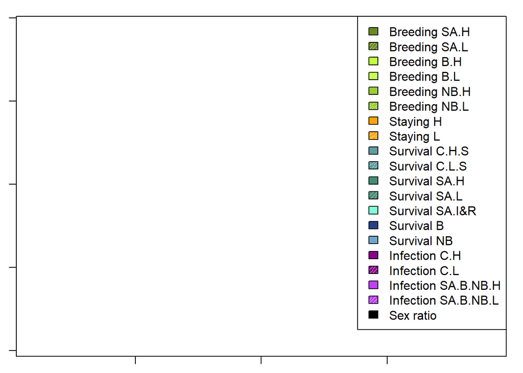

```r
#mtext(side = 3,text=c("b) epidem"),adj=0, line =1.7,cex = 1.3)



# Overall legend

#rm(list=ls()) # remove all objects/memory
#gc()

par(mar=c(1.1,1.1,1.1,1.1))
plot(sensNew1$sens_epidem, pch ="",xlab="",ylab="")

legend("topright",

c("Breeding SA.H","Breeding SA.L","Breeding B.H","Breeding B.L","Breeding NB.H","Breeding NB.L",
 "Staying H","Staying L",
 "Survival C.H.S","Survival C.L.S", "Survival SA.H","Survival SA.L","Survival SA.I&R", "Survival B","Survival NB",
 "Infection C.H", "Infection C.L", "Infection SA.B.NB.H","Infection SA.B.NB.L",
 "Sex ratio")
       ,
       fill= c("olivedrab4", "olivedrab4", "olivedrab1","olivedrab1","olivedrab3","olivedrab3",
               "orange1","orange1",
               "cadetblue","cadetblue","aquamarine4","aquamarine4","aquamarine1","royalblue4","skyblue3",
               "darkmagenta","darkmagenta","darkorchid1","darkorchid1",
               "gray0")
,
       density = c(NA,80,NA,80,NA,80,
                   NA,80,
                   NA,80,NA,80,NA,NA,NA,
                   NA,80,NA,80,
                   NA))
```

## References (R packages)

Stubben, C. & Milligan, B. Estimating and analyzing demographic models using the popbio package in R. J. Stat. Softw 22, 1-23 (2007).

Stott, I., Hodgson, D. J. & Townley, S. popdemo: an R package for population demography using projection matrix analysis. Methods Ecol. Evol. 3, 797-802 (2012).